# Risk Factor Analysis

## Outcome Variable

**Outcome Variable:** stunted

## Predictor Variables

**Intervention Variable:** fage

**Adjustment Set:**

unadjusted

## Stratifying Variables

The analysis was stratified on these variable(s):

- agecat
- studyid
- country

## Data Summary

| agecat | studyid | country | A | n | nA | nAY0 | nAY1 |
| --- | --- | --- | --- | --- | --- | --- | --- |
| Birth | ki0047075b-MAL-ED | BANGLADESH | >=35 | 145 | 99 | 83 | 16 |
| Birth | ki0047075b-MAL-ED | BANGLADESH | <25 | 145 | 0 | 0 | 0 |
| Birth | ki0047075b-MAL-ED | BANGLADESH | [25-30) | 145 | 13 | 11 | 2 |
| Birth | ki0047075b-MAL-ED | BANGLADESH | [30-35) | 145 | 33 | 31 | 2 |
| Birth | ki0047075b-MAL-ED | BRAZIL | >=35 | 68 | 35 | 31 | 4 |
| Birth | ki0047075b-MAL-ED | BRAZIL | <25 | 68 | 3 | 3 | 0 |
| Birth | ki0047075b-MAL-ED | BRAZIL | [25-30) | 68 | 7 | 7 | 0 |
| Birth | ki0047075b-MAL-ED | BRAZIL | [30-35) | 68 | 23 | 20 | 3 |
| Birth | ki0047075b-MAL-ED | INDIA | >=35 | 131 | 57 | 49 | 8 |
| Birth | ki0047075b-MAL-ED | INDIA | <25 | 131 | 2 | 2 | 0 |
| Birth | ki0047075b-MAL-ED | INDIA | [25-30) | 131 | 24 | 20 | 4 |
| Birth | ki0047075b-MAL-ED | INDIA | [30-35) | 131 | 48 | 40 | 8 |
| Birth | ki0047075b-MAL-ED | NEPAL | >=35 | 61 | 31 | 28 | 3 |
| Birth | ki0047075b-MAL-ED | NEPAL | <25 | 61 | 0 | 0 | 0 |
| Birth | ki0047075b-MAL-ED | NEPAL | [25-30) | 61 | 6 | 6 | 0 |
| Birth | ki0047075b-MAL-ED | NEPAL | [30-35) | 61 | 24 | 22 | 2 |
| Birth | ki0047075b-MAL-ED | PERU | >=35 | 80 | 42 | 40 | 2 |
| Birth | ki0047075b-MAL-ED | PERU | <25 | 80 | 4 | 3 | 1 |
| Birth | ki0047075b-MAL-ED | PERU | [25-30) | 80 | 17 | 15 | 2 |
| Birth | ki0047075b-MAL-ED | PERU | [30-35) | 80 | 17 | 12 | 5 |
| Birth | ki0047075b-MAL-ED | SOUTH AFRICA | >=35 | 76 | 63 | 56 | 7 |
| Birth | ki0047075b-MAL-ED | SOUTH AFRICA | <25 | 76 | 1 | 1 | 0 |
| Birth | ki0047075b-MAL-ED | SOUTH AFRICA | [25-30) | 76 | 5 | 4 | 1 |
| Birth | ki0047075b-MAL-ED | SOUTH AFRICA | [30-35) | 76 | 7 | 6 | 1 |
| Birth | ki0047075b-MAL-ED | TANZANIA, UNITED REPUBLIC OF | >=35 | 46 | 27 | 24 | 3 |
| Birth | ki0047075b-MAL-ED | TANZANIA, UNITED REPUBLIC OF | <25 | 46 | 1 | 1 | 0 |
| Birth | ki0047075b-MAL-ED | TANZANIA, UNITED REPUBLIC OF | [25-30) | 46 | 3 | 3 | 0 |
| Birth | ki0047075b-MAL-ED | TANZANIA, UNITED REPUBLIC OF | [30-35) | 46 | 15 | 13 | 2 |
| Birth | ki1135781-COHORTS | GUATEMALA | >=35 | 390 | 155 | 147 | 8 |
| Birth | ki1135781-COHORTS | GUATEMALA | <25 | 390 | 65 | 63 | 2 |

[output cut: 262 more lines]

The following strata were considered:

- agecat: 12 months, studyid: ki0047075b-MAL-ED, country: BANGLADESH
- agecat: 12 months, studyid: ki0047075b-MAL-ED, country: BRAZIL
- agecat: 12 months, studyid: ki0047075b-MAL-ED, country: INDIA
- agecat: 12 months, studyid: ki0047075b-MAL-ED, country: NEPAL
- agecat: 12 months, studyid: ki0047075b-MAL-ED, country: PERU
- agecat: 12 months, studyid: ki0047075b-MAL-ED, country: SOUTH AFRICA
- agecat: 12 months, studyid: ki0047075b-MAL-ED, country: TANZANIA, UNITED REPUBLIC OF
- agecat: 12 months, studyid: ki1000304b-SAS-FoodSuppl, country: INDIA
- agecat: 12 months, studyid: ki1135781-COHORTS, country: GUATEMALA
- agecat: 12 months, studyid: ki1135781-COHORTS, country: PHILIPPINES
- agecat: 12 months, studyid: ki1148112-LCNI-5, country: MALAWI
- agecat: 18 months, studyid: ki0047075b-MAL-ED, country: BANGLADESH
- agecat: 18 months, studyid: ki0047075b-MAL-ED, country: BRAZIL
- agecat: 18 months, studyid: ki0047075b-MAL-ED, country: INDIA
- agecat: 18 months, studyid: ki0047075b-MAL-ED, country: NEPAL
- agecat: 18 months, studyid: ki0047075b-MAL-ED, country: PERU
- agecat: 18 months, studyid: ki0047075b-MAL-ED, country: SOUTH AFRICA
- agecat: 18 months, studyid: ki0047075b-MAL-ED, country: TANZANIA, UNITED REPUBLIC OF
- agecat: 18 months, studyid: ki1000304b-SAS-FoodSuppl, country: INDIA
- agecat: 18 months, studyid: ki1135781-COHORTS, country: GUATEMALA
- agecat: 18 months, studyid: ki1135781-COHORTS, country: PHILIPPINES
- agecat: 18 months, studyid: ki1148112-LCNI-5, country: MALAWI
- agecat: 24 months, studyid: ki0047075b-MAL-ED, country: BANGLADESH
- agecat: 24 months, studyid: ki0047075b-MAL-ED, country: BRAZIL
- agecat: 24 months, studyid: ki0047075b-MAL-ED, country: INDIA
- agecat: 24 months, studyid: ki0047075b-MAL-ED, country: NEPAL
- agecat: 24 months, studyid: ki0047075b-MAL-ED, country: PERU
- agecat: 24 months, studyid: ki0047075b-MAL-ED, country: SOUTH AFRICA
- agecat: 24 months, studyid: ki0047075b-MAL-ED, country: TANZANIA, UNITED REPUBLIC OF
- agecat: 24 months, studyid: ki1135781-COHORTS, country: GUATEMALA
- agecat: 24 months, studyid: ki1135781-COHORTS, country: PHILIPPINES
- agecat: 24 months, studyid: ki1148112-LCNI-5, country: MALAWI
- agecat: 3 months, studyid: ki0047075b-MAL-ED, country: BANGLADESH
- agecat: 3 months, studyid: ki0047075b-MAL-ED, country: BRAZIL
- agecat: 3 months, studyid: ki0047075b-MAL-ED, country: INDIA
- agecat: 3 months, studyid: ki0047075b-MAL-ED, country: NEPAL
- agecat: 3 months, studyid: ki0047075b-MAL-ED, country: PERU
- agecat: 3 months, studyid: ki0047075b-MAL-ED, country: SOUTH AFRICA
- agecat: 3 months, studyid: ki0047075b-MAL-ED, country: TANZANIA, UNITED REPUBLIC OF
- agecat: 3 months, studyid: ki1000304b-SAS-FoodSuppl, country: INDIA
- agecat: 3 months, studyid: ki1135781-COHORTS, country: GUATEMALA
- agecat: 3 months, studyid: ki1135781-COHORTS, country: PHILIPPINES
- agecat: 6 months, studyid: ki0047075b-MAL-ED, country: BANGLADESH
- agecat: 6 months, studyid: ki0047075b-MAL-ED, country: BRAZIL
- agecat: 6 months, studyid: ki0047075b-MAL-ED, country: INDIA
- agecat: 6 months, studyid: ki0047075b-MAL-ED, country: NEPAL
- agecat: 6 months, studyid: ki0047075b-MAL-ED, country: PERU
- agecat: 6 months, studyid: ki0047075b-MAL-ED, country: SOUTH AFRICA
- agecat: 6 months, studyid: ki0047075b-MAL-ED, country: TANZANIA, UNITED REPUBLIC OF
- agecat: 6 months, studyid: ki1000304b-SAS-FoodSuppl, country: INDIA
- agecat: 6 months, studyid: ki1135781-COHORTS, country: GUATEMALA
- agecat: 6 months, studyid: ki1135781-COHORTS, country: PHILIPPINES
- agecat: 6 months, studyid: ki1148112-LCNI-5, country: MALAWI
- agecat: 9 months, studyid: ki0047075b-MAL-ED, country: BANGLADESH
- agecat: 9 months, studyid: ki0047075b-MAL-ED, country: BRAZIL
- agecat: 9 months, studyid: ki0047075b-MAL-ED, country: INDIA
- agecat: 9 months, studyid: ki0047075b-MAL-ED, country: NEPAL
- agecat: 9 months, studyid: ki0047075b-MAL-ED, country: PERU
- agecat: 9 months, studyid: ki0047075b-MAL-ED, country: SOUTH AFRICA
- agecat: 9 months, studyid: ki0047075b-MAL-ED, country: TANZANIA, UNITED REPUBLIC OF
- agecat: 9 months, studyid: ki1000304b-SAS-FoodSuppl, country: INDIA
- agecat: 9 months, studyid: ki1135781-COHORTS, country: GUATEMALA
- agecat: 9 months, studyid: ki1135781-COHORTS, country: PHILIPPINES
- agecat: 9 months, studyid: ki1148112-LCNI-5, country: MALAWI
- agecat: Birth, studyid: ki0047075b-MAL-ED, country: BANGLADESH
- agecat: Birth, studyid: ki0047075b-MAL-ED, country: BRAZIL
- agecat: Birth, studyid: ki0047075b-MAL-ED, country: INDIA
- agecat: Birth, studyid: ki0047075b-MAL-ED, country: NEPAL
- agecat: Birth, studyid: ki0047075b-MAL-ED, country: PERU
- agecat: Birth, studyid: ki0047075b-MAL-ED, country: SOUTH AFRICA
- agecat: Birth, studyid: ki0047075b-MAL-ED, country: TANZANIA, UNITED REPUBLIC OF
- agecat: Birth, studyid: ki1135781-COHORTS, country: GUATEMALA
- agecat: Birth, studyid: ki1135781-COHORTS, country: PHILIPPINES

### Dropped Strata

Some strata were dropped due to rare outcomes:

- agecat: Birth, studyid: ki0047075b-MAL-ED, country: BANGLADESH
- agecat: Birth, studyid: ki0047075b-MAL-ED, country: BRAZIL
- agecat: Birth, studyid: ki0047075b-MAL-ED, country: INDIA
- agecat: Birth, studyid: ki0047075b-MAL-ED, country: NEPAL
- agecat: Birth, studyid: ki0047075b-MAL-ED, country: PERU
- agecat: Birth, studyid: ki0047075b-MAL-ED, country: SOUTH AFRICA
- agecat: Birth, studyid: ki0047075b-MAL-ED, country: TANZANIA, UNITED REPUBLIC OF
- agecat: Birth, studyid: ki1135781-COHORTS, country: GUATEMALA
- agecat: 3 months, studyid: ki0047075b-MAL-ED, country: BANGLADESH
- agecat: 3 months, studyid: ki0047075b-MAL-ED, country: BRAZIL
- agecat: 3 months, studyid: ki0047075b-MAL-ED, country: INDIA
- agecat: 3 months, studyid: ki0047075b-MAL-ED, country: NEPAL
- agecat: 3 months, studyid: ki0047075b-MAL-ED, country: PERU
- agecat: 3 months, studyid: ki0047075b-MAL-ED, country: SOUTH AFRICA
- agecat: 3 months, studyid: ki0047075b-MAL-ED, country: TANZANIA, UNITED REPUBLIC OF
- agecat: 6 months, studyid: ki0047075b-MAL-ED, country: BANGLADESH
- agecat: 6 months, studyid: ki0047075b-MAL-ED, country: BRAZIL
- agecat: 6 months, studyid: ki0047075b-MAL-ED, country: INDIA
- agecat: 6 months, studyid: ki0047075b-MAL-ED, country: NEPAL
- agecat: 6 months, studyid: ki0047075b-MAL-ED, country: PERU
- agecat: 6 months, studyid: ki0047075b-MAL-ED, country: SOUTH AFRICA
- agecat: 6 months, studyid: ki0047075b-MAL-ED, country: TANZANIA, UNITED REPUBLIC OF
- agecat: 9 months, studyid: ki0047075b-MAL-ED, country: BANGLADESH
- agecat: 9 months, studyid: ki0047075b-MAL-ED, country: BRAZIL
- agecat: 9 months, studyid: ki0047075b-MAL-ED, country: INDIA
- agecat: 9 months, studyid: ki0047075b-MAL-ED, country: NEPAL
- agecat: 9 months, studyid: ki0047075b-MAL-ED, country: PERU
- agecat: 9 months, studyid: ki0047075b-MAL-ED, country: SOUTH AFRICA
- agecat: 9 months, studyid: ki0047075b-MAL-ED, country: TANZANIA, UNITED REPUBLIC OF
- agecat: 9 months, studyid: ki1000304b-SAS-FoodSuppl, country: INDIA
- agecat: 12 months, studyid: ki0047075b-MAL-ED, country: BANGLADESH
- agecat: 12 months, studyid: ki0047075b-MAL-ED, country: BRAZIL
- agecat: 12 months, studyid: ki0047075b-MAL-ED, country: INDIA
- agecat: 12 months, studyid: ki0047075b-MAL-ED, country: NEPAL
- agecat: 12 months, studyid: ki0047075b-MAL-ED, country: PERU
- agecat: 12 months, studyid: ki0047075b-MAL-ED, country: SOUTH AFRICA
- agecat: 12 months, studyid: ki0047075b-MAL-ED, country: TANZANIA, UNITED REPUBLIC OF
- agecat: 12 months, studyid: ki1000304b-SAS-FoodSuppl, country: INDIA
- agecat: 18 months, studyid: ki0047075b-MAL-ED, country: BANGLADESH
- agecat: 18 months, studyid: ki0047075b-MAL-ED, country: BRAZIL
- agecat: 18 months, studyid: ki0047075b-MAL-ED, country: INDIA
- agecat: 18 months, studyid: ki0047075b-MAL-ED, country: NEPAL
- agecat: 18 months, studyid: ki0047075b-MAL-ED, country: PERU
- agecat: 18 months, studyid: ki0047075b-MAL-ED, country: SOUTH AFRICA
- agecat: 18 months, studyid: ki0047075b-MAL-ED, country: TANZANIA, UNITED REPUBLIC OF
- agecat: 18 months, studyid: ki1000304b-SAS-FoodSuppl, country: INDIA
- agecat: 24 months, studyid: ki0047075b-MAL-ED, country: BANGLADESH
- agecat: 24 months, studyid: ki0047075b-MAL-ED, country: BRAZIL
- agecat: 24 months, studyid: ki0047075b-MAL-ED, country: INDIA
- agecat: 24 months, studyid: ki0047075b-MAL-ED, country: NEPAL
- agecat: 24 months, studyid: ki0047075b-MAL-ED, country: PERU
- agecat: 24 months, studyid: ki0047075b-MAL-ED, country: SOUTH AFRICA
- agecat: 24 months, studyid: ki0047075b-MAL-ED, country: TANZANIA, UNITED REPUBLIC OF
- agecat: 24 months, studyid: ki1148112-LCNI-5, country: MALAWI

## Methods Detail

We’re interested in the causal parameters $E[Y_a]$ for all values of $a \in \mathcal{A}$. These parameters represent the mean outcome if, possibly contrary to fact, we intervened to set all units to have $A=a$. Under the randomization and positivity assumptions, these are identified by the statistical parameters $\psi_a=E_W[E_{Y|A,W}(Y|A=a,W)]$. In addition, we’re interested in the mean of $Y$, $E[Y]$ under no intervention (the observed mean). We will estimate these parameters by using SuperLearner to fit the relevant likelihood factors – $E_{Y|A,W}(Y|A=a,W)$ and $p(A=a|W)$, and then updating our likelihood fit using a joint TMLE.

For unadjusted analyses ($W=\{\}$), initial likelihoods were estimated using Lrnr_glm to estimate the simple $E(Y|A)$ and Lrnr_mean to estimate $p(A)$. For adjusted analyses, a small library containing Lrnr_glmnet, Lrnr_xgboost, and Lrnr_mean was used.

Having estimated these parameters, we will then use the delta method to estimate relative risks and attributable risks relative to a prespecified baseline level of $A$.

# Results Detail

## Results Plots

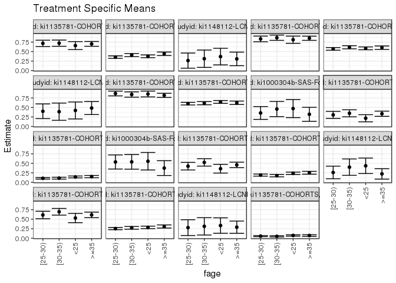

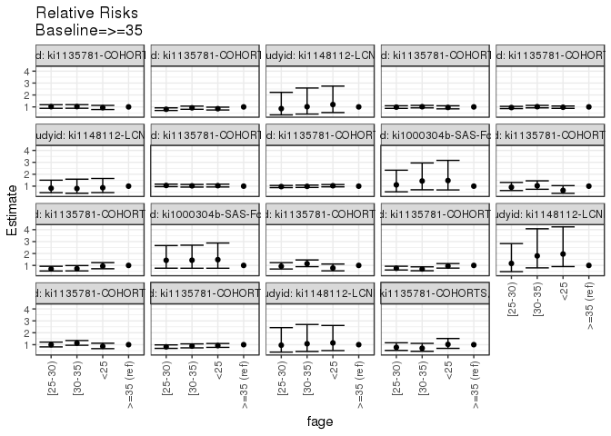

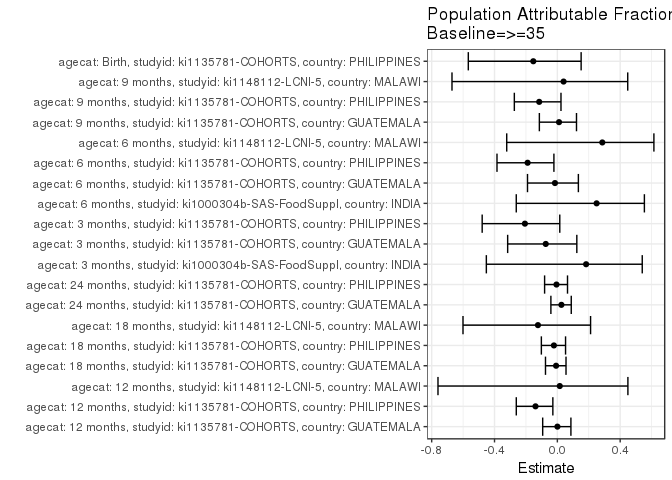

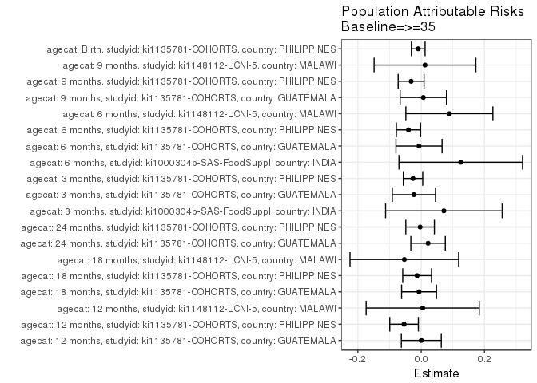

## Results Table

### Parameter: TSM

| agecat | studyid | country | intervention_level | baseline_level | estimate | ci_lower | ci_upper |
| --- | --- | --- | --- | --- | --- | --- | --- |
| Birth | ki1135781-COHORTS | PHILIPPINES | >=35 | NA | 0.0705009 | 0.0488862 | 0.0921156 |
| Birth | ki1135781-COHORTS | PHILIPPINES | <25 | NA | 0.0721393 | 0.0542530 | 0.0900256 |
| Birth | ki1135781-COHORTS | PHILIPPINES | [25-30) | NA | 0.0545073 | 0.0400993 | 0.0689154 |
| Birth | ki1135781-COHORTS | PHILIPPINES | [30-35) | NA | 0.0494590 | 0.0327490 | 0.0661691 |
| 3 months | ki1000304b-SAS-FoodSuppl | INDIA | >=35 | NA | 0.3200000 | 0.1361948 | 0.5038052 |
| 3 months | ki1000304b-SAS-FoodSuppl | INDIA | <25 | NA | 0.4705882 | 0.2320867 | 0.7090898 |
| 3 months | ki1000304b-SAS-FoodSuppl | INDIA | [25-30) | NA | 0.3548387 | 0.1855347 | 0.5241427 |
| 3 months | ki1000304b-SAS-FoodSuppl | INDIA | [30-35) | NA | 0.4583333 | 0.2579556 | 0.6587111 |
| 3 months | ki1135781-COHORTS | GUATEMALA | >=35 | NA | 0.3351351 | 0.2670399 | 0.4032304 |
| 3 months | ki1135781-COHORTS | GUATEMALA | <25 | NA | 0.2162162 | 0.1223191 | 0.3101133 |
| 3 months | ki1135781-COHORTS | GUATEMALA | [25-30) | NA | 0.3052632 | 0.2125564 | 0.3979699 |
| 3 months | ki1135781-COHORTS | GUATEMALA | [30-35) | NA | 0.3465347 | 0.2536274 | 0.4394419 |
| 3 months | ki1135781-COHORTS | PHILIPPINES | >=35 | NA | 0.1507634 | 0.1201210 | 0.1814058 |
| 3 months | ki1135781-COHORTS | PHILIPPINES | <25 | NA | 0.1420912 | 0.1170323 | 0.1671500 |
| 3 months | ki1135781-COHORTS | PHILIPPINES | [25-30) | NA | 0.1060268 | 0.0858644 | 0.1261892 |
| 3 months | ki1135781-COHORTS | PHILIPPINES | [30-35) | NA | 0.1098546 | 0.0852158 | 0.1344935 |
| 6 months | ki1000304b-SAS-FoodSuppl | INDIA | >=35 | NA | 0.3750000 | 0.1802973 | 0.5697027 |
| 6 months | ki1000304b-SAS-FoodSuppl | INDIA | <25 | NA | 0.5555556 | 0.3247968 | 0.7863143 |
| 6 months | ki1000304b-SAS-FoodSuppl | INDIA | [25-30) | NA | 0.5357143 | 0.3500185 | 0.7214101 |
| 6 months | ki1000304b-SAS-FoodSuppl | INDIA | [30-35) | NA | 0.5384615 | 0.3458348 | 0.7310883 |
| 6 months | ki1135781-COHORTS | GUATEMALA | >=35 | NA | 0.4585635 | 0.3858909 | 0.5312362 |
| 6 months | ki1135781-COHORTS | GUATEMALA | <25 | NA | 0.3582090 | 0.2432708 | 0.4731471 |
| 6 months | ki1135781-COHORTS | GUATEMALA | [25-30) | NA | 0.4255319 | 0.3254693 | 0.5255945 |
| 6 months | ki1135781-COHORTS | GUATEMALA | [30-35) | NA | 0.5242718 | 0.4277166 | 0.6208271 |
| 6 months | ki1135781-COHORTS | PHILIPPINES | >=35 | NA | 0.2520161 | 0.2137997 | 0.2902326 |
| 6 months | ki1135781-COHORTS | PHILIPPINES | <25 | NA | 0.2380952 | 0.2068483 | 0.2693422 |
| 6 months | ki1135781-COHORTS | PHILIPPINES | [25-30) | NA | 0.1906475 | 0.1639831 | 0.2173119 |
| 6 months | ki1135781-COHORTS | PHILIPPINES | [30-35) | NA | 0.1758621 | 0.1448734 | 0.2068507 |
| 6 months | ki1148112-LCNI-5 | MALAWI | >=35 | NA | 0.2222222 | 0.0857713 | 0.3586732 |
| 6 months | ki1148112-LCNI-5 | MALAWI | <25 | NA | 0.4347826 | 0.2312255 | 0.6383397 |
| 6 months | ki1148112-LCNI-5 | MALAWI | [25-30) | NA | 0.2592593 | 0.0931764 | 0.4253421 |
| 6 months | ki1148112-LCNI-5 | MALAWI | [30-35) | NA | 0.4000000 | 0.1842767 | 0.6157233 |
| 9 months | ki1135781-COHORTS | GUATEMALA | >=35 | NA | 0.6140351 | 0.5409851 | 0.6870851 |
| 9 months | ki1135781-COHORTS | GUATEMALA | <25 | NA | 0.5312500 | 0.4088510 | 0.6536490 |
| 9 months | ki1135781-COHORTS | GUATEMALA | [25-30) | NA | 0.6105263 | 0.5123567 | 0.7086960 |
| 9 months | ki1135781-COHORTS | GUATEMALA | [30-35) | NA | 0.6952381 | 0.6070926 | 0.7833836 |
| 9 months | ki1135781-COHORTS | PHILIPPINES | >=35 | NA | 0.3081633 | 0.2672725 | 0.3490540 |
| 9 months | ki1135781-COHORTS | PHILIPPINES | <25 | NA | 0.2841226 | 0.2511281 | 0.3171170 |
| 9 months | ki1135781-COHORTS | PHILIPPINES | [25-30) | NA | 0.2532699 | 0.2238727 | 0.2826671 |
| 9 months | ki1135781-COHORTS | PHILIPPINES | [30-35) | NA | 0.2728843 | 0.2365947 | 0.3091739 |
| 9 months | ki1148112-LCNI-5 | MALAWI | >=35 | NA | 0.2903226 | 0.1295996 | 0.4510455 |
| 9 months | ki1148112-LCNI-5 | MALAWI | <25 | NA | 0.3333333 | 0.1305315 | 0.5361352 |
| 9 months | ki1148112-LCNI-5 | MALAWI | [25-30) | NA | 0.2777778 | 0.0696473 | 0.4859083 |
| 9 months | ki1148112-LCNI-5 | MALAWI | [30-35) | NA | 0.3125000 | 0.0840510 | 0.5409490 |
| 12 months | ki1135781-COHORTS | GUATEMALA | >=35 | NA | 0.7029703 | 0.6398938 | 0.7660468 |
| 12 months | ki1135781-COHORTS | GUATEMALA | <25 | NA | 0.6582278 | 0.5535348 | 0.7629209 |
| 12 months | ki1135781-COHORTS | GUATEMALA | [25-30) | NA | 0.7168142 | 0.6336617 | 0.7999666 |
| 12 months | ki1135781-COHORTS | GUATEMALA | [30-35) | NA | 0.7217391 | 0.6397526 | 0.8037256 |
| 12 months | ki1135781-COHORTS | PHILIPPINES | >=35 | NA | 0.4430108 | 0.3978523 | 0.4881692 |
| 12 months | ki1135781-COHORTS | PHILIPPINES | <25 | NA | 0.3761062 | 0.3396366 | 0.4125757 |
| 12 months | ki1135781-COHORTS | PHILIPPINES | [25-30) | NA | 0.3551171 | 0.3221751 | 0.3880592 |
| 12 months | ki1135781-COHORTS | PHILIPPINES | [30-35) | NA | 0.4086799 | 0.3676996 | 0.4496602 |
| 12 months | ki1148112-LCNI-5 | MALAWI | >=35 | NA | 0.3076923 | 0.1291666 | 0.4862180 |
| 12 months | ki1148112-LCNI-5 | MALAWI | <25 | NA | 0.3684211 | 0.1501537 | 0.5866884 |
| 12 months | ki1148112-LCNI-5 | MALAWI | [25-30) | NA | 0.2631579 | 0.0639080 | 0.4624078 |
| 12 months | ki1148112-LCNI-5 | MALAWI | [30-35) | NA | 0.3125000 | 0.0839502 | 0.5410498 |
| 18 months | ki1135781-COHORTS | GUATEMALA | >=35 | NA | 0.8509317 | 0.7958513 | 0.9060120 |
| 18 months | ki1135781-COHORTS | GUATEMALA | <25 | NA | 0.8125000 | 0.7167604 | 0.9082396 |
| 18 months | ki1135781-COHORTS | GUATEMALA | [25-30) | NA | 0.8333333 | 0.7586940 | 0.9079726 |
| 18 months | ki1135781-COHORTS | GUATEMALA | [30-35) | NA | 0.8645833 | 0.7960545 | 0.9331122 |
| 18 months | ki1135781-COHORTS | PHILIPPINES | >=35 | NA | 0.6031390 | 0.5577241 | 0.6485539 |
| 18 months | ki1135781-COHORTS | PHILIPPINES | <25 | NA | 0.5856269 | 0.5478649 | 0.6233889 |
| 18 months | ki1135781-COHORTS | PHILIPPINES | [25-30) | NA | 0.5708812 | 0.5362060 | 0.6055564 |
| 18 months | ki1135781-COHORTS | PHILIPPINES | [30-35) | NA | 0.6135084 | 0.5721604 | 0.6548565 |
| 18 months | ki1148112-LCNI-5 | MALAWI | >=35 | NA | 0.4848485 | 0.3134293 | 0.6562677 |
| 18 months | ki1148112-LCNI-5 | MALAWI | <25 | NA | 0.4210526 | 0.1978718 | 0.6442335 |
| 18 months | ki1148112-LCNI-5 | MALAWI | [25-30) | NA | 0.4000000 | 0.2069448 | 0.5930552 |
| 18 months | ki1148112-LCNI-5 | MALAWI | [30-35) | NA | 0.3888889 | 0.1624857 | 0.6152921 |
| 24 months | ki1135781-COHORTS | GUATEMALA | >=35 | NA | 0.8186528 | 0.7642385 | 0.8730672 |
| 24 months | ki1135781-COHORTS | GUATEMALA | <25 | NA | 0.8536585 | 0.7770802 | 0.9302369 |
| 24 months | ki1135781-COHORTS | GUATEMALA | [25-30) | NA | 0.8672566 | 0.8046345 | 0.9298788 |
| 24 months | ki1135781-COHORTS | GUATEMALA | [30-35) | NA | 0.8411215 | 0.7717857 | 0.9104573 |
| 24 months | ki1135781-COHORTS | PHILIPPINES | >=35 | NA | 0.6230248 | 0.5778864 | 0.6681633 |
| 24 months | ki1135781-COHORTS | PHILIPPINES | <25 | NA | 0.6450617 | 0.6082124 | 0.6819110 |
| 24 months | ki1135781-COHORTS | PHILIPPINES | [25-30) | NA | 0.6005256 | 0.5657193 | 0.6353319 |
| 24 months | ki1135781-COHORTS | PHILIPPINES | [30-35) | NA | 0.6127168 | 0.5707988 | 0.6546347 |

### Parameter: E(Y)

| agecat | studyid | country | intervention_level | baseline_level | estimate | ci_lower | ci_upper |
| --- | --- | --- | --- | --- | --- | --- | --- |
| Birth | ki1135781-COHORTS | PHILIPPINES | NA | NA | 0.0611413 | 0.0607923 | 0.0614903 |
| 3 months | ki1000304b-SAS-FoodSuppl | INDIA | NA | NA | 0.3917526 | 0.3791828 | 0.4043223 |
| 3 months | ki1135781-COHORTS | GUATEMALA | NA | NA | 0.3120879 | 0.3079907 | 0.3161851 |
| 3 months | ki1135781-COHORTS | PHILIPPINES | NA | NA | 0.1249551 | 0.1242407 | 0.1256696 |
| 6 months | ki1000304b-SAS-FoodSuppl | INDIA | NA | NA | 0.5000000 | 0.4854192 | 0.5145808 |
| 6 months | ki1135781-COHORTS | GUATEMALA | NA | NA | 0.4516854 | 0.4468532 | 0.4565176 |
| 6 months | ki1135781-COHORTS | PHILIPPINES | NA | NA | 0.2118902 | 0.2107285 | 0.2130520 |
| 6 months | ki1148112-LCNI-5 | MALAWI | NA | NA | 0.3113208 | 0.2940238 | 0.3286177 |
| 9 months | ki1135781-COHORTS | GUATEMALA | NA | NA | 0.6206897 | 0.6159310 | 0.6254483 |
| 9 months | ki1135781-COHORTS | PHILIPPINES | NA | NA | 0.2762557 | 0.2755119 | 0.2769995 |
| 9 months | ki1148112-LCNI-5 | MALAWI | NA | NA | 0.3023256 | 0.2979065 | 0.3067446 |
| 12 months | ki1135781-COHORTS | GUATEMALA | NA | NA | 0.7033399 | 0.7015310 | 0.7051488 |
| 12 months | ki1135781-COHORTS | PHILIPPINES | NA | NA | 0.3889110 | 0.3876467 | 0.3901754 |
| 12 months | ki1148112-LCNI-5 | MALAWI | NA | NA | 0.3125000 | 0.3044628 | 0.3205372 |
| 18 months | ki1135781-COHORTS | GUATEMALA | NA | NA | 0.8441247 | 0.8424755 | 0.8457739 |
| 18 months | ki1135781-COHORTS | PHILIPPINES | NA | NA | 0.5902318 | 0.5895675 | 0.5908960 |
| 18 months | ki1148112-LCNI-5 | MALAWI | NA | NA | 0.4315789 | 0.4234534 | 0.4397045 |
| 24 months | ki1135781-COHORTS | GUATEMALA | NA | NA | 0.8404040 | 0.8386889 | 0.8421192 |
| 24 months | ki1135781-COHORTS | PHILIPPINES | NA | NA | 0.6195698 | 0.6188649 | 0.6202747 |

### Parameter: RR

| agecat | studyid | country | intervention_level | baseline_level | estimate | ci_lower | ci_upper |
| --- | --- | --- | --- | --- | --- | --- | --- |
| Birth | ki1135781-COHORTS | PHILIPPINES | >=35 | >=35 | 1.0000000 | 1.0000000 | 1.0000000 |
| Birth | ki1135781-COHORTS | PHILIPPINES | <25 | >=35 | 1.0232391 | 0.6898198 | 1.5178141 |
| Birth | ki1135781-COHORTS | PHILIPPINES | [25-30) | >=35 | 0.7731436 | 0.5157693 | 1.1589502 |
| Birth | ki1135781-COHORTS | PHILIPPINES | [30-35) | >=35 | 0.7015375 | 0.4445433 | 1.1071021 |
| 3 months | ki1000304b-SAS-FoodSuppl | INDIA | >=35 | >=35 | 1.0000000 | 1.0000000 | 1.0000000 |
| 3 months | ki1000304b-SAS-FoodSuppl | INDIA | <25 | >=35 | 1.4705882 | 0.6836166 | 3.1635128 |
| 3 months | ki1000304b-SAS-FoodSuppl | INDIA | [25-30) | >=35 | 1.1088710 | 0.5255190 | 2.3397723 |
| 3 months | ki1000304b-SAS-FoodSuppl | INDIA | [30-35) | >=35 | 1.4322917 | 0.6958869 | 2.9479781 |
| 3 months | ki1135781-COHORTS | GUATEMALA | >=35 | >=35 | 1.0000000 | 1.0000000 | 1.0000000 |
| 3 months | ki1135781-COHORTS | GUATEMALA | <25 | >=35 | 0.6451613 | 0.3994319 | 1.0420628 |
| 3 months | ki1135781-COHORTS | GUATEMALA | [25-30) | >=35 | 0.9108659 | 0.6320686 | 1.3126370 |
| 3 months | ki1135781-COHORTS | GUATEMALA | [30-35) | >=35 | 1.0340147 | 0.7386354 | 1.4475157 |
| 3 months | ki1135781-COHORTS | PHILIPPINES | >=35 | >=35 | 1.0000000 | 1.0000000 | 1.0000000 |
| 3 months | ki1135781-COHORTS | PHILIPPINES | <25 | >=35 | 0.9424780 | 0.7201202 | 1.2334952 |
| 3 months | ki1135781-COHORTS | PHILIPPINES | [25-30) | >=35 | 0.7032663 | 0.5324015 | 0.9289671 |
| 3 months | ki1135781-COHORTS | PHILIPPINES | [30-35) | >=35 | 0.7286559 | 0.5383578 | 0.9862202 |
| 6 months | ki1000304b-SAS-FoodSuppl | INDIA | >=35 | >=35 | 1.0000000 | 1.0000000 | 1.0000000 |
| 6 months | ki1000304b-SAS-FoodSuppl | INDIA | <25 | >=35 | 1.4814815 | 0.7619556 | 2.8804662 |
| 6 months | ki1000304b-SAS-FoodSuppl | INDIA | [25-30) | >=35 | 1.4285714 | 0.7652072 | 2.6670113 |
| 6 months | ki1000304b-SAS-FoodSuppl | INDIA | [30-35) | >=35 | 1.4358974 | 0.7643526 | 2.6974482 |
| 6 months | ki1135781-COHORTS | GUATEMALA | >=35 | >=35 | 1.0000000 | 1.0000000 | 1.0000000 |
| 6 months | ki1135781-COHORTS | GUATEMALA | <25 | >=35 | 0.7811545 | 0.5461539 | 1.1172718 |
| 6 months | ki1135781-COHORTS | GUATEMALA | [25-30) | >=35 | 0.9279672 | 0.6988460 | 1.2322073 |
| 6 months | ki1135781-COHORTS | GUATEMALA | [30-35) | >=35 | 1.1432916 | 0.8966784 | 1.4577308 |
| 6 months | ki1135781-COHORTS | PHILIPPINES | >=35 | >=35 | 1.0000000 | 1.0000000 | 1.0000000 |
| 6 months | ki1135781-COHORTS | PHILIPPINES | <25 | >=35 | 0.9447619 | 0.7730833 | 1.1545651 |
| 6 months | ki1135781-COHORTS | PHILIPPINES | [25-30) | >=35 | 0.7564892 | 0.6154752 | 0.9298115 |
| 6 months | ki1135781-COHORTS | PHILIPPINES | [30-35) | >=35 | 0.6978207 | 0.5530703 | 0.8804553 |
| 6 months | ki1148112-LCNI-5 | MALAWI | >=35 | >=35 | 1.0000000 | 1.0000000 | 1.0000000 |
| 6 months | ki1148112-LCNI-5 | MALAWI | <25 | >=35 | 1.9565217 | 0.9039436 | 4.2347526 |
| 6 months | ki1148112-LCNI-5 | MALAWI | [25-30) | >=35 | 1.1666667 | 0.4803650 | 2.8334932 |
| 6 months | ki1148112-LCNI-5 | MALAWI | [30-35) | >=35 | 1.8000000 | 0.7949660 | 4.0756458 |
| 9 months | ki1135781-COHORTS | GUATEMALA | >=35 | >=35 | 1.0000000 | 1.0000000 | 1.0000000 |
| 9 months | ki1135781-COHORTS | GUATEMALA | <25 | >=35 | 0.8651786 | 0.6675644 | 1.1212910 |
| 9 months | ki1135781-COHORTS | GUATEMALA | [25-30) | >=35 | 0.9942857 | 0.8140355 | 1.2144484 |
| 9 months | ki1135781-COHORTS | GUATEMALA | [30-35) | >=35 | 1.1322449 | 0.9515544 | 1.3472466 |
| 9 months | ki1135781-COHORTS | PHILIPPINES | >=35 | >=35 | 1.0000000 | 1.0000000 | 1.0000000 |
| 9 months | ki1135781-COHORTS | PHILIPPINES | <25 | >=35 | 0.9219871 | 0.7729389 | 1.0997768 |
| 9 months | ki1135781-COHORTS | PHILIPPINES | [25-30) | >=35 | 0.8218693 | 0.6890318 | 0.9803162 |
| 9 months | ki1135781-COHORTS | PHILIPPINES | [30-35) | >=35 | 0.8855185 | 0.7338548 | 1.0685263 |
| 9 months | ki1148112-LCNI-5 | MALAWI | >=35 | >=35 | 1.0000000 | 1.0000000 | 1.0000000 |
| 9 months | ki1148112-LCNI-5 | MALAWI | <25 | >=35 | 1.1481481 | 0.5043797 | 2.6135949 |
| 9 months | ki1148112-LCNI-5 | MALAWI | [25-30) | >=35 | 0.9567901 | 0.3769013 | 2.4288780 |
| 9 months | ki1148112-LCNI-5 | MALAWI | [30-35) | >=35 | 1.0763889 | 0.4302503 | 2.6928817 |
| 12 months | ki1135781-COHORTS | GUATEMALA | >=35 | >=35 | 1.0000000 | 1.0000000 | 1.0000000 |
| 12 months | ki1135781-COHORTS | GUATEMALA | <25 | >=35 | 0.9363523 | 0.7800629 | 1.1239551 |
| 12 months | ki1135781-COHORTS | GUATEMALA | [25-30) | >=35 | 1.0196934 | 0.8805984 | 1.1807591 |
| 12 months | ki1135781-COHORTS | GUATEMALA | [30-35) | >=35 | 1.0266993 | 0.8883317 | 1.1866193 |
| 12 months | ki1135781-COHORTS | PHILIPPINES | >=35 | >=35 | 1.0000000 | 1.0000000 | 1.0000000 |
| 12 months | ki1135781-COHORTS | PHILIPPINES | <25 | >=35 | 0.8489776 | 0.7375577 | 0.9772292 |
| 12 months | ki1135781-COHORTS | PHILIPPINES | [25-30) | >=35 | 0.8015994 | 0.6983938 | 0.9200561 |
| 12 months | ki1135781-COHORTS | PHILIPPINES | [30-35) | >=35 | 0.9225057 | 0.7995944 | 1.0643105 |
| 12 months | ki1148112-LCNI-5 | MALAWI | >=35 | >=35 | 1.0000000 | 1.0000000 | 1.0000000 |
| 12 months | ki1148112-LCNI-5 | MALAWI | <25 | >=35 | 1.1973684 | 0.5225124 | 2.7438416 |
| 12 months | ki1148112-LCNI-5 | MALAWI | [25-30) | >=35 | 0.8552632 | 0.3294792 | 2.2200949 |
| 12 months | ki1148112-LCNI-5 | MALAWI | [30-35) | >=35 | 1.0156250 | 0.3992958 | 2.5832832 |
| 18 months | ki1135781-COHORTS | GUATEMALA | >=35 | >=35 | 1.0000000 | 1.0000000 | 1.0000000 |
| 18 months | ki1135781-COHORTS | GUATEMALA | <25 | >=35 | 0.9548358 | 0.8347210 | 1.0922349 |
| 18 months | ki1135781-COHORTS | GUATEMALA | [25-30) | >=35 | 0.9793187 | 0.8768610 | 1.0937483 |
| 18 months | ki1135781-COHORTS | GUATEMALA | [30-35) | >=35 | 1.0160432 | 0.9172099 | 1.1255262 |
| 18 months | ki1135781-COHORTS | PHILIPPINES | >=35 | >=35 | 1.0000000 | 1.0000000 | 1.0000000 |
| 18 months | ki1135781-COHORTS | PHILIPPINES | <25 | >=35 | 0.9709651 | 0.8793266 | 1.0721536 |
| 18 months | ki1135781-COHORTS | PHILIPPINES | [25-30) | >=35 | 0.9465168 | 0.8592386 | 1.0426605 |
| 18 months | ki1135781-COHORTS | PHILIPPINES | [30-35) | >=35 | 1.0171924 | 0.9194240 | 1.1253572 |
| 18 months | ki1148112-LCNI-5 | MALAWI | >=35 | >=35 | 1.0000000 | 1.0000000 | 1.0000000 |
| 18 months | ki1148112-LCNI-5 | MALAWI | <25 | >=35 | 0.8684211 | 0.4592199 | 1.6422526 |
| 18 months | ki1148112-LCNI-5 | MALAWI | [25-30) | >=35 | 0.8250000 | 0.4535492 | 1.5006642 |
| 18 months | ki1148112-LCNI-5 | MALAWI | [30-35) | >=35 | 0.8020833 | 0.4058919 | 1.5849977 |
| 24 months | ki1135781-COHORTS | GUATEMALA | >=35 | >=35 | 1.0000000 | 1.0000000 | 1.0000000 |
| 24 months | ki1135781-COHORTS | GUATEMALA | <25 | >=35 | 1.0427601 | 0.9326022 | 1.1659297 |
| 24 months | ki1135781-COHORTS | GUATEMALA | [25-30) | >=35 | 1.0593704 | 0.9603404 | 1.1686124 |
| 24 months | ki1135781-COHORTS | GUATEMALA | [30-35) | >=35 | 1.0274459 | 0.9242098 | 1.1422136 |
| 24 months | ki1135781-COHORTS | PHILIPPINES | >=35 | >=35 | 1.0000000 | 1.0000000 | 1.0000000 |
| 24 months | ki1135781-COHORTS | PHILIPPINES | <25 | >=35 | 1.0353708 | 0.9441192 | 1.1354422 |
| 24 months | ki1135781-COHORTS | PHILIPPINES | [25-30) | >=35 | 0.9638871 | 0.8784796 | 1.0575981 |
| 24 months | ki1135781-COHORTS | PHILIPPINES | [30-35) | >=35 | 0.9834548 | 0.8901812 | 1.0865017 |

### Parameter: PAR

| agecat | studyid | country | intervention_level | baseline_level | estimate | ci_lower | ci_upper |
| --- | --- | --- | --- | --- | --- | --- | --- |
| Birth | ki1135781-COHORTS | PHILIPPINES | >=35 | NA | -0.0093596 | -0.0309771 | 0.0122579 |
| 3 months | ki1000304b-SAS-FoodSuppl | INDIA | >=35 | NA | 0.0717526 | -0.1124819 | 0.2559871 |
| 3 months | ki1135781-COHORTS | GUATEMALA | >=35 | NA | -0.0230472 | -0.0912656 | 0.0451712 |
| 3 months | ki1135781-COHORTS | PHILIPPINES | >=35 | NA | -0.0258082 | -0.0564590 | 0.0048425 |
| 6 months | ki1000304b-SAS-FoodSuppl | INDIA | >=35 | NA | 0.1250000 | -0.0702479 | 0.3202479 |
| 6 months | ki1135781-COHORTS | GUATEMALA | >=35 | NA | -0.0068781 | -0.0797112 | 0.0659550 |
| 6 months | ki1135781-COHORTS | PHILIPPINES | >=35 | NA | -0.0401259 | -0.0783600 | -0.0018918 |
| 6 months | ki1148112-LCNI-5 | MALAWI | >=35 | NA | 0.0890985 | -0.0484444 | 0.2266414 |
| 9 months | ki1135781-COHORTS | GUATEMALA | >=35 | NA | 0.0066546 | -0.0665503 | 0.0798594 |
| 9 months | ki1135781-COHORTS | PHILIPPINES | >=35 | NA | -0.0319076 | -0.0728051 | 0.0089899 |
| 9 months | ki1148112-LCNI-5 | MALAWI | >=35 | NA | 0.0120030 | -0.1487807 | 0.1727867 |
| 12 months | ki1135781-COHORTS | GUATEMALA | >=35 | NA | 0.0003696 | -0.0627329 | 0.0634721 |
| 12 months | ki1135781-COHORTS | PHILIPPINES | >=35 | NA | -0.0540997 | -0.0992758 | -0.0089236 |
| 12 months | ki1148112-LCNI-5 | MALAWI | >=35 | NA | 0.0048077 | -0.1738988 | 0.1835142 |
| 18 months | ki1135781-COHORTS | GUATEMALA | >=35 | NA | -0.0068070 | -0.0619120 | 0.0482980 |
| 18 months | ki1135781-COHORTS | PHILIPPINES | >=35 | NA | -0.0129072 | -0.0583270 | 0.0325125 |
| 18 months | ki1148112-LCNI-5 | MALAWI | >=35 | NA | -0.0532695 | -0.2248812 | 0.1183422 |
| 24 months | ki1135781-COHORTS | GUATEMALA | >=35 | NA | 0.0217512 | -0.0326902 | 0.0761926 |
| 24 months | ki1135781-COHORTS | PHILIPPINES | >=35 | NA | -0.0034550 | -0.0485990 | 0.0416889 |

### Parameter: PAF

| agecat | studyid | country | intervention_level | baseline_level | estimate | ci_lower | ci_upper |
| --- | --- | --- | --- | --- | --- | --- | --- |
| Birth | ki1135781-COHORTS | PHILIPPINES | >=35 | NA | -0.1530818 | -0.5668683 | 0.1514298 |
| 3 months | ki1000304b-SAS-FoodSuppl | INDIA | >=35 | NA | 0.1831579 | -0.4520513 | 0.5404907 |
| 3 months | ki1135781-COHORTS | GUATEMALA | >=35 | NA | -0.0738485 | -0.3163463 | 0.1239763 |
| 3 months | ki1135781-COHORTS | PHILIPPINES | >=35 | NA | -0.2065401 | -0.4785850 | 0.0154512 |
| 6 months | ki1000304b-SAS-FoodSuppl | INDIA | >=35 | NA | 0.2500000 | -0.2615528 | 0.5541209 |
| 6 months | ki1135781-COHORTS | GUATEMALA | >=35 | NA | -0.0152277 | -0.1899990 | 0.1338755 |
| 6 months | ki1135781-COHORTS | PHILIPPINES | >=35 | NA | -0.1893711 | -0.3842613 | -0.0219195 |
| 6 months | ki1148112-LCNI-5 | MALAWI | >=35 | NA | 0.2861953 | -0.3223256 | 0.6146810 |
| 9 months | ki1135781-COHORTS | GUATEMALA | >=35 | NA | 0.0107212 | -0.1145323 | 0.1218985 |
| 9 months | ki1135781-COHORTS | PHILIPPINES | >=35 | NA | -0.1155001 | -0.2738221 | 0.0231443 |
| 9 months | ki1148112-LCNI-5 | MALAWI | >=35 | NA | 0.0397022 | -0.6707662 | 0.4480546 |
| 12 months | ki1135781-COHORTS | GUATEMALA | >=35 | NA | 0.0005255 | -0.0933429 | 0.0863348 |
| 12 months | ki1135781-COHORTS | PHILIPPINES | >=35 | NA | -0.1391056 | -0.2614104 | -0.0286593 |
| 12 months | ki1148112-LCNI-5 | MALAWI | >=35 | NA | 0.0153846 | -0.7599301 | 0.4491444 |
| 18 months | ki1135781-COHORTS | GUATEMALA | >=35 | NA | -0.0080639 | -0.0755052 | 0.0551483 |
| 18 months | ki1135781-COHORTS | PHILIPPINES | >=35 | NA | -0.0218681 | -0.1017925 | 0.0522586 |
| 18 months | ki1148112-LCNI-5 | MALAWI | >=35 | NA | -0.1234294 | -0.6006969 | 0.2115349 |
| 24 months | ki1135781-COHORTS | GUATEMALA | >=35 | NA | 0.0258818 | -0.0410990 | 0.0885533 |
| 24 months | ki1135781-COHORTS | PHILIPPINES | >=35 | NA | -0.0055765 | -0.0811448 | 0.0647098 |